# Análise Exploratória de Dados em R

05/11/2026

## Parte I · O que é a EDA?

## Análise Exploratória de Dados

A expressão vem de John Tukey (*Exploratory Data Analysis*, 1977). A ideia central é simples: antes de testar hipóteses, devemos **olhar** para os dados e deixar que eles nos mostrem a sua estrutura.

A análise confirmatória pergunta *“os dados apoiam a minha hipótese?”*. A análise exploratória pergunta *“o que é que estes dados têm para me contar?”*.

Na investigação em psicologia isto é especialmente importante, porque trabalhamos com escalas Likert, amostras pequenas, valores em falta, respostas extremas e distribuições que raramente são normais. Uma boa EDA evita que um teste estatístico nos dê uma resposta certa à pergunta errada.

## Porque é que a EDA importa?

Uma EDA cuidadosa serve para:

1. **Conhecer a qualidade dos dados**, detetando erros de codificação, valores impossíveis (uma idade de 230 anos) ou respostas em falta.
2. **Compreender as distribuições**, percebendo se são simétricas, enviesadas, multimodais ou com tetos e chãos.
3. **Identificar outliers** e decidir de forma fundamentada o que fazer com eles.
4. **Verificar pressupostos** dos modelos que vamos usar depois (normalidade, homogeneidade de variâncias, linearidade).
5. **Gerar hipóteses** e descobrir relações que não esperávamos.

O famoso quarteto de Anscombe mostra quatro conjuntos de dados com médias, variâncias e correlações praticamente iguais, mas com gráficos completamente diferentes. Os números sozinhos não chegam.

## O quarteto de Anscombe

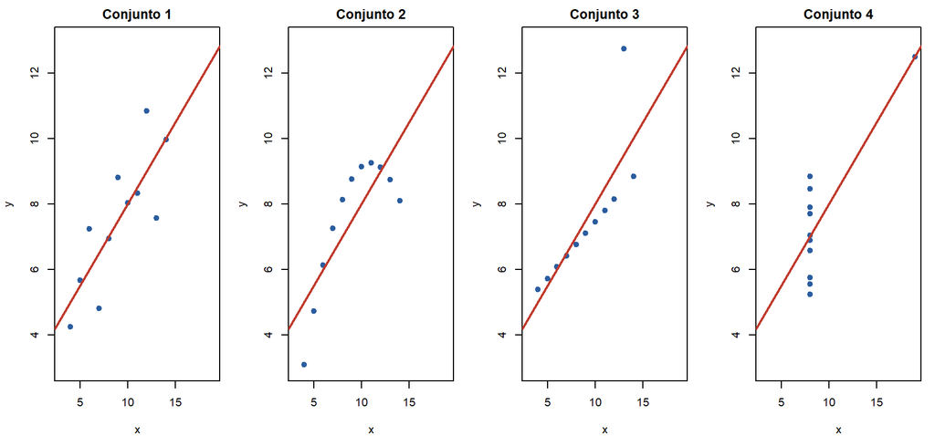

Em todos: média de *x* ≈ 9, média de *y* ≈ 7.5, *r* ≈ 0.82. Mesmas estatísticas, histórias muito diferentes.

## O que inclui normalmente uma EDA?

| Etapa | Perguntas típicas | Ferramentas em R |
| --- | --- | --- |
| **1. Estrutura** | Quantos casos e variáveis? De que tipo? | `str()`, `head()`, `names()`, `class()` |
| **2. Qualidade** | Há valores em falta? Valores impossíveis? | `summary()`, `is.na()`, `table()` |
| **3. Univariada** | Como se distribui cada variável? | `mean()`, `median()`, `sd()`, `hist()`, `boxplot()` |
| **4. Bivariada** | Como se relacionam as variáveis entre si? | `table()`, `cor()`, `plot()` |
| **5. Preparação** | Que variáveis recodificar ou criar? | `factor()`, `ifelse()` |
| **6. Relatório** | Como comunicar o que encontrei? | `psych::describe()`, `DataExplorer` |

Na prática estas etapas não são lineares: andamos para trás e para a frente muitas vezes.

## O tipo de variável manda na análise

Antes de calcular seja o que for, temos de saber **que tipo de variável** temos, porque isso determina que medidas e gráficos fazem sentido.

| Tipo | Exemplo em psicologia | Tendência central | Dispersão | Gráfico |
| --- | --- | --- | --- | --- |
| Nominal | Sexo, estado civil | Moda | Frequências | Barras |
| Ordinal | Item Likert | Mediana, moda | Amplitude interquartil | Barras |
| Discreta | Nº de sessões de terapia | Média, mediana | DP, AIQ | Barras, histograma |
| Contínua | Tempo de reação, IMC | Média, mediana | DP, variância, AIQ | Histograma, boxplot |

Em R, as variáveis qualitativas devem ser guardadas como `factor`; as ordinais como `factor(..., ordered = TRUE)`.

## Parte II · Um exemplo prático

## O plano do exemplo

Vamos seguir um percurso em duas fases.

**Fase 1, dados simulados.** Criamos variáveis de cada tipo, juntamo-las numa base de dados e calculamos medidas de tendência central e de dispersão.

**Fase 2, dados reais.** Importamos uma base do SPSS, preparamos as variáveis (recodificar, criar, categorizar) e geramos um relatório exploratório automático.

Todo o código destes slides pode ser corrido diretamente no RStudio. Para a segunda fase é preciso ter o ficheiro `Base AQUES.sav` na mesma pasta que este documento.

## 1.1 Variáveis qualitativas: nominais

```r
# Um vetor de texto simples
nominal <- c("green", "blue", "yellow", "red", "blue")

# Um fator sem ordem: cidades de Portugal
non_ordered <- factor(c("Porto", "Lisboa", "Braga", "Aveiro", "Coimbra"))

# Uma amostra aleatória de 50 cidades
city <- sample(non_ordered, 50, replace = TRUE)
table(city)
```

```
## city
##  Aveiro   Braga Coimbra  Lisboa   Porto
##      10       7      16      10       7
```

Um `factor` guarda as categorias possíveis (os *levels*). É assim que o R sabe que a variável é qualitativa.

## 1.1 Variáveis qualitativas: ordinais

```r
ordered_levels <- c("strongly disagree", "disagree", "neutral",
                    "agree", "strongly agree")

satisfaction <- factor(sample(ordered_levels, 50, replace = TRUE),
                       levels  = ordered_levels,
                       ordered = TRUE)

head(satisfaction)
```

```
## [1] strongly disagree neutral           strongly agree    strongly agree
## [5] strongly disagree agree
## 5 Levels: strongly disagree < disagree < neutral < ... < strongly agree
```

O argumento `ordered = TRUE` diz ao R que existe uma ordem entre as categorias, tal como numa escala Likert. Repare no símbolo `<` entre os níveis.

## 1.2 Variáveis quantitativas

```r
# Discreta: número de dias de trabalho por semana (0 a 7)
weekdays_worked <- rbinom(50, 7, prob = 0.5)

# Contínua: salário mensal em euros
salary <- rnorm(50, mean = 1200, sd = 300)
```

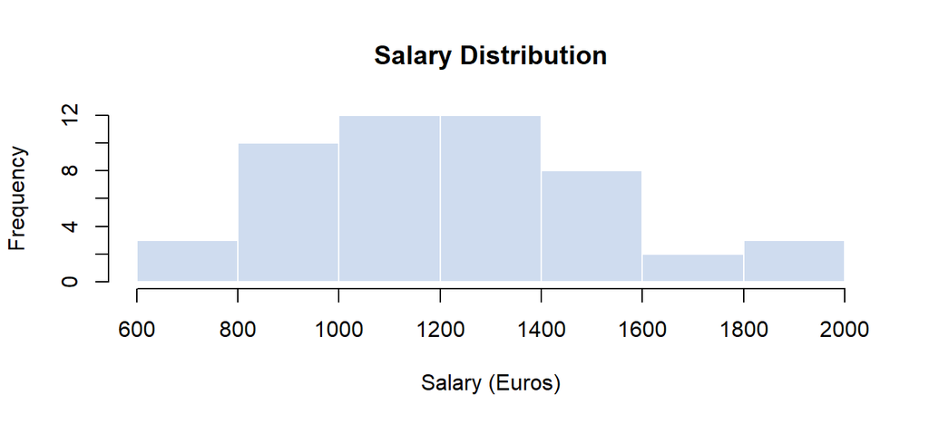

```r
hist(salary, main = "Salary Distribution", xlab = "Salary (Euros)",
     col = "#cfdcef", border = "white")
```

## 2. Juntar tudo numa base de dados

```r
data <- data.frame(color        = nominal,
                   city         = city,
                   satisfaction = satisfaction,
                   weekdays     = weekdays_worked,
                   salary       = salary)
summary(data)
```

```
##        color         city               satisfaction    weekdays
##  Length   :50   Aveiro :10   strongly disagree:13    Min.   :1.00
##  N.unique : 4   Braga  : 7   disagree         : 5    1st Qu.:2.00
##  N.blank  : 0   Coimbra:16   neutral          : 7    Median :3.50
##  Min.nchar: 3   Lisboa :10   agree            :12    Mean   :3.36
##  Max.nchar: 6   Porto  : 7   strongly agree   :13    3rd Qu.:4.00
##                                                      Max.   :6.00
##      salary
##  Min.   : 678.4
##  1st Qu.: 999.2
##  Median :1216.7
##  Mean   :1230.1
##  3rd Qu.:1435.0
##  Max.   :1991.6
```

Repare que `nominal` só tem 5 valores. O R “recicla-o” até chegar aos 50 casos, o que funciona porque 50 é múltiplo de 5, mas é um comportamento a que convém estar atento.

## 3. Medidas de tendência central

**Moda**, para variáveis nominais:

```r
color_table <- table(data$color)
most_frequent_color <- names(which.max(color_table))
print(paste("The most frequent color is:", most_frequent_color))
```

```
## [1] "The most frequent color is: blue"
```

**Média**, para variáveis quantitativas:

```r
mean(data$weekdays)
```

```
## [1] 3.36
```

## 3. A mediana e um erro instrutivo

```r
median(data$satisfaction)
```

```
## Error in `median.default()`:
## ! need numeric data
```

O R pode recusar calcular a mediana de um fator (ou devolver uma categoria em vez de um número, dependendo da versão). A solução é trabalhar com a posição de cada categoria:

```r
median(as.numeric(data$satisfaction))
```

```
## [1] 3.5
```

```r
levels(data$satisfaction)[median(as.numeric(data$satisfaction))]
```

```
## [1] "neutral"
```

Os erros fazem parte da aprendizagem: ler a mensagem de erro é muitas vezes a forma mais rápida de perceber o que o R espera.

## 4. Medidas de dispersão

```r
range(data$salary)    # amplitude total (mínimo e máximo)
```

```
## [1]  678.3622 1991.6122
```

```r
IQR(data$salary)      # amplitude interquartil: os 50% centrais
```

```
## [1] 435.7454
```

```r
var(data$salary)      # variância
```

```
## [1] 98677.52
```

```r
sd(data$salary)       # desvio-padrão
```

```
## [1] 314.1298
```

## 4. O boxplot resume a dispersão

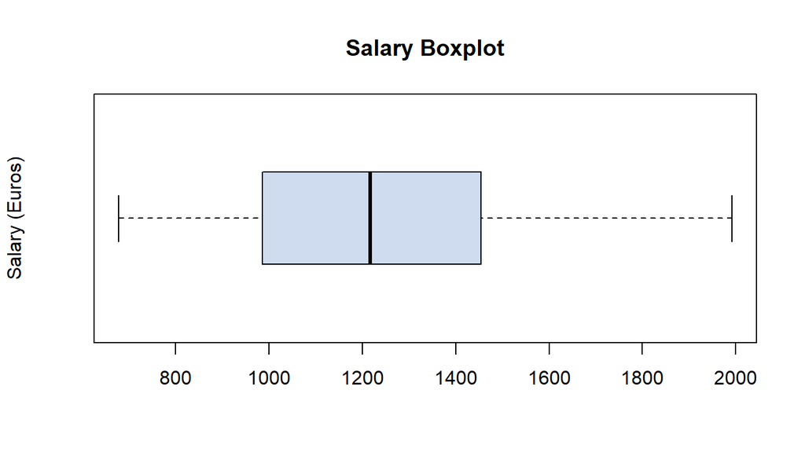

```r
boxplot(data$salary, main = "Salary Boxplot", ylab = "Salary (Euros)",
        col = "#cfdcef", horizontal = TRUE)
```

A caixa corresponde à amplitude interquartil, a linha central é a mediana e os pontos isolados são potenciais outliers (valores a mais de 1.5 × AIQ da caixa).

## Primeira paragem

Acabámos de criar e analisar a nossa primeira base de dados em R!

Até aqui vimos como:

- criar variáveis de diferentes tipos
- juntá-las numa `data.frame`
- calcular moda, mediana e média
- descrever a dispersão com amplitude, AIQ, variância e desvio-padrão
- visualizar distribuições com histogramas e boxplots

Agora passamos a dados reais.

## 5. Importar dados do SPSS

O pacote `haven` lê ficheiros `.sav` mantendo os rótulos das variáveis.

```r
# install.packages("haven")   # se necessário
library(haven)

data_spss <- read_sav("Base AQUES.sav")
head(data_spss)
```

## 5. Uma primeira descrição

`summary()` dá uma visão rápida; `psych::describe()` acrescenta assimetria, curtose e erro-padrão, muito úteis em psicologia.

```r
library(psych)
describe(data_spss)
```

Valores de assimetria ou curtose muito afastados de 0 são um sinal para olhar com atenção para a distribuição dessa variável.

## 6.1 Conhecer as variáveis

```r
class(data_spss)
names(data_spss)
```

Este é o momento de confirmar que cada variável tem o tipo certo. No SPSS, o sexo pode estar codificado como 0 e 1, mas para o R isso é um número, não uma categoria.

## 6.2 Recodificar variáveis

```r
data_spss$sex <- factor(data_spss$sex, levels = c(0, 1),
                        labels = c("male", "female"))
data_spss$country <- factor(data_spss$country, levels = c(1, 2),
                            labels = c("Australia", "elsewhere"))

table(data_spss$country, data_spss$sex)
```

## 6.2 Visualizar duas variáveis categóricas

```r
plot(data_spss$country, data_spss$sex,
     xlab = "Country", ylab = "Sex", col = c("#cfdcef", "#2a5d9f"))
```

Quando as duas variáveis são fatores, `plot()` desenha um *spineplot*: a largura das colunas reflete o tamanho de cada grupo e a altura a proporção de cada sexo.

## 6.3 Converter várias variáveis em fatores

```r
varnames <- c("parsport", "enstat", "firstb", "pastsmok",
              "marital", "expect", "employ")

# as_factor() usa os rótulos guardados no ficheiro SPSS
data_spss[, varnames] <- lapply(data_spss[, varnames], as_factor)

# parsport tem uma ordem natural
data_spss$parsport <- factor(data_spss$parsport, ordered = TRUE)
```

`lapply()` aplica a mesma função a uma lista de variáveis, o que poupa muito código repetido.

## 6.4 e 6.5 Criar e categorizar variáveis

```r
# Calcular o IMC a partir do peso (kg) e da altura (cm)
data_spss$bmi <- data_spss$weight / (data_spss$height / 100)^2

# Agrupar o IMC nas categorias da OMS
data_spss$bmi_cat <- cut(data_spss$bmi,
                         breaks = c(-Inf, 18.5, 25, 30, Inf),
                         labels = c("underweight", "normal weight",
                                    "overweight", "obesity"),
                         right = FALSE, ordered_result = TRUE)
table(data_spss$bmi_cat)
```

O script original usa `ifelse()` encadeados, que dá o mesmo resultado. `cut()` é uma alternativa mais compacta e menos sujeita a erros quando há muitas categorias.

## 7. EDA automática com DataExplorer

Existem vários pacotes que geram relatórios exploratórios completos com uma só linha. Uma boa lista está [neste post do R-bloggers](https://www.r-bloggers.com/2024/10/top-10-r-packages-for-exploratory-data-analysis-eda-bookmark-this/).

```r
# install.packages("DataExplorer")   # se necessário
library(DataExplorer)
create_report(data_spss)
```

O relatório inclui a estrutura da base, os valores em falta, histogramas, gráficos de barras, gráficos QQ, a matriz de correlações e uma análise de componentes principais.

Os relatórios automáticos são um excelente ponto de partida, mas não substituem o nosso juízo: cabe-nos a nós decidir o que é relevante.

## 7. Uma espreitadela ao relatório

```r
library(DataExplorer)
plot_missing(data_spss)
```

## Para levar para casa

Importámos, preparámos e explorámos uma base de dados real em R!

Uma EDA bem feita responde a três perguntas antes de qualquer teste estatístico: os dados estão corretos? Como se distribuem? Como se relacionam?

Em R, o percurso típico é **importar → inspecionar → recodificar → descrever → visualizar → reportar**, e as funções que vimos hoje cobrem a maior parte desse caminho.

O próximo passo é praticar com os vossos próprios dados. Quanto mais o fizerem, mais natural se torna.

## Alguns recursos

- Tukey, J. W. (1977). *Exploratory Data Analysis*. Addison-Wesley.
- Wickham, H., Çetinkaya-Rundel, M., & Grolemund, G. (2023). *R for Data Science* (2.ª ed.), capítulo sobre EDA. Disponível em r4ds.hadley.nz.
- Revelle, W. Documentação do pacote `psych`: [personality-project.org/r/psych](https://personality-project.org/r/psych/).
- [Top 10 R packages for EDA (R-bloggers, 2024)](https://www.r-bloggers.com/2024/10/top-10-r-packages-for-exploratory-data-analysis-eda-bookmark-this/)

**Obrigado!**